# Exercise 2: Data in R

2024-10-09

# Classes in R

Classes are more specific data types in R.

```r
num <- 2.2
class(num)
```

```
## [1] "numeric"
```

```r
char <- "hello"
class(char)
```

```
## [1] "character"
```

```r
logi <- TRUE
class(logi)
```

```
## [1] "logical"
```

Alternatively, you can ask if an object is a specific class using using a logical test. The is.classOfData family of functions will return either a TRUE or a FALSE.

```r
is.numeric(num)
```

```
## [1] TRUE
```

```r
is.character(num)
```

```
## [1] FALSE
```

```r
is.character(char)
```

```
## [1] TRUE
```

```r
is.logical(logi)
```

```
## [1] TRUE
```

You can coerce objects into classes sometimes.

```r
# numeric to character
class(num)
```

```
## [1] "numeric"
```

```r
num_char <-  as.character(num)
num_char
```

```
## [1] "2.2"
```

```r
class(num_char)
```

```
## [1] "character"
```

```r
# character to numeric
class(char)
```

```
## [1] "character"
```

```r
char_num <- as.numeric(char)
```

Another useful data structure used in many disciplines such as population ecology, theoretical and applied statistics is the matrix. A matrix is simply a vector that has additional attributes called dimensions. Arrays are just multidimensional matrices. Again, matrices and arrays must contain elements all of the same data class.

```r
my_mat <- matrix(1:16, nrow = 4, byrow = TRUE)
my_mat
```

```
##      [,1] [,2] [,3] [,4]
## [1,]    1    2    3    4
## [2,]    5    6    7    8
## [3,]    9   10   11   12
## [4,]   13   14   15   16
```

```r
my_array <- array(1:16, dim = c(2, 4, 2))
my_array
```

```
## , , 1
##
##      [,1] [,2] [,3] [,4]
## [1,]    1    3    5    7
## [2,]    2    4    6    8
##
## , , 2
##
##      [,1] [,2] [,3] [,4]
## [1,]    9   11   13   15
## [2,]   10   12   14   16
```

Sometimes it’s also useful to define row and column names for your matrix but this is not a requirement. To do this use the rownames() and colnames() functions.

```r
rownames(my_mat) <- c("A", "B", "C", "D")
colnames(my_mat) <- c("a", "b", "c", "d")
my_mat
```

```
##    a  b  c  d
## A  1  2  3  4
## B  5  6  7  8
## C  9 10 11 12
## D 13 14 15 16
```

# Matrix operations

```r
my_mat_t <- t(my_mat)
my_mat_t
```

```
##   A B  C  D
## a 1 5  9 13
## b 2 6 10 14
## c 3 7 11 15
## d 4 8 12 16
```

```r
my_mat_diag <- diag(my_mat)
my_mat_diag
```

```
## [1]  1  6 11 16
```

```r
mat.1 <- matrix(c(2, 0, 1, 1), nrow = 2)    # notice that the matrix has been filled
mat.1                                     # column-wise by default
```

```
##      [,1] [,2]
## [1,]    2    1
## [2,]    0    1
```

```r
mat.2 <- matrix(c(1, 1, 0, 2), nrow = 2)
mat.2
```

```
##      [,1] [,2]
## [1,]    1    0
## [2,]    1    2
```

```r
mat.1 + mat.2           # matrix addition
```

```
##      [,1] [,2]
## [1,]    3    1
## [2,]    1    3
```

```r
mat.1 * mat.2           # element by element products
```

```
##      [,1] [,2]
## [1,]    2    0
## [2,]    0    2
```

```r
mat.1 %*% mat.2         # matrix multiplication
```

```
##      [,1] [,2]
## [1,]    3    2
## [2,]    1    2
```

# List

Lists are able to store mixtures of data types. In fact we can even store other data structures such as vectors and arrays within a list or even have a list of a list. This makes for a very flexible data structure which is ideal for storing irregular or non-rectangular data.

```r
list_1 <- list(c("black", "yellow", "orange"),
               c(TRUE, TRUE, FALSE, TRUE, FALSE, FALSE),
               matrix(1:6, nrow = 3))
list_1
```

```
## [[1]]
## [1] "black"  "yellow" "orange"
##
## [[2]]
## [1]  TRUE  TRUE FALSE  TRUE FALSE FALSE
##
## [[3]]
##      [,1] [,2]
## [1,]    1    4
## [2,]    2    5
## [3,]    3    6
```

```r
list_2 <- list(colours = c("black", "yellow", "orange"),
               evaluation = c(TRUE, TRUE, FALSE, TRUE, FALSE, FALSE),
               time = matrix(1:6, nrow = 3))
list_2
```

```
## $colours
## [1] "black"  "yellow" "orange"
##
## $evaluation
## [1]  TRUE  TRUE FALSE  TRUE FALSE FALSE
##
## $time
##      [,1] [,2]
## [1,]    1    4
## [2,]    2    5
## [3,]    3    6
```

```r
names(list_1) <- c("colours", "evaluation", "time")
list_1
```

```
## $colours
## [1] "black"  "yellow" "orange"
##
## $evaluation
## [1]  TRUE  TRUE FALSE  TRUE FALSE FALSE
##
## $time
##      [,1] [,2]
## [1,]    1    4
## [2,]    2    5
## [3,]    3    6
```

# Data frames

```r
p.height <- c(180, 155, 160, 167, 181)
p.weight <- c(65, 50, 52, 58, 70)
p.names <- c("Joanna", "Charlotte", "Helen", "Karen", "Amy")

dataf <- data.frame(height = p.height, weight = p.weight, names = p.names)
dataf
```

```
##   height weight     names
## 1    180     65    Joanna
## 2    155     50 Charlotte
## 3    160     52     Helen
## 4    167     58     Karen
## 5    181     70       Amy
```

```r
dim(dataf)   # 5 rows and 3 columns
```

```
## [1] 5 3
```

```r
str(dataf)
```

```
## 'data.frame':    5 obs. of  3 variables:
##  $ height: num  180 155 160 167 181
##  $ weight: num  65 50 52 58 70
##  $ names : chr  "Joanna" "Charlotte" "Helen" "Karen" ...
```

# Reading in files

```r
setwd("~/tanzania/")
flowers <- read.csv(file = 'flower.csv', header = TRUE, stringsAsFactors = TRUE)
str(flowers)
```

```
## 'data.frame':    96 obs. of  8 variables:
##  $ treat    : Factor w/ 2 levels "notip","tip": 2 2 2 2 2 2 2 2 2 2 ...
##  $ nitrogen : Factor w/ 3 levels "high","low","medium": 3 3 3 3 3 3 3 3 3 3 ...
##  $ block    : int  1 1 1 1 1 1 1 1 2 2 ...
##  $ height   : num  7.5 10.7 11.2 10.4 10.4 9.8 6.9 9.4 10.4 12.3 ...
##  $ weight   : num  7.62 12.14 12.76 8.78 13.58 ...
##  $ leafarea : num  11.7 14.1 7.1 11.9 14.5 12.2 13.2 14 10.5 16.1 ...
##  $ shootarea: num  31.9 46 66.7 20.3 26.9 72.7 43.1 28.5 57.8 36.9 ...
##  $ flowers  : int  1 10 10 1 4 9 7 6 5 8 ...
```

```r
names(flowers)
```

```
## [1] "treat"     "nitrogen"  "block"     "height"    "weight"    "leafarea"
## [7] "shootarea" "flowers"
```

# Working with dataframes

```r
flowers$height
```

```
##  [1]  7.5 10.7 11.2 10.4 10.4  9.8  6.9  9.4 10.4 12.3 10.4 11.0  7.1  6.0  9.0
## [16]  4.5 12.6 10.0 10.0  8.5 14.1 10.1  8.5  6.5 11.5  7.7  6.4  8.8  9.2  6.2
## [31]  6.3 17.2  8.0  8.0  6.4  7.6  9.7 12.3  9.1  8.9  7.4  3.1  7.9  8.8  8.5
## [46]  5.6 11.5  5.8  5.6  5.3  7.5  4.1  3.5  8.5  4.9  2.5  5.4  3.9  5.8  4.5
## [61]  8.0  1.8  2.2  3.9  8.5  8.5  6.4  1.2  2.6 10.9  7.2  2.1  4.7  5.0  6.5
## [76]  2.6  6.0  9.3  4.6  5.2  3.9  2.3  5.2  2.2  4.5  1.8  3.0  3.7  2.4  5.7
## [91]  3.7  3.2  3.9  3.3  5.5  4.4
```

```r
f_height <- flowers$height
mean(f_height)
```

```
## [1] 6.839583
```

```r
summary(f_height)
```

```
##    Min. 1st Qu.  Median    Mean 3rd Qu.    Max.
##   1.200   4.475   6.450   6.840   9.025  17.200
```

```r
mean(flowers$height)
```

```
## [1] 6.839583
```

```r
summary(flowers$height)
```

```
##    Min. 1st Qu.  Median    Mean 3rd Qu.    Max.
##   1.200   4.475   6.450   6.840   9.025  17.200
```

Using indexes

```r
flowers[1, 4]
```

```
## [1] 7.5
```

```r
# this would give you the same
flowers$height[1]
```

```
## [1] 7.5
```

```r
flowers[1:10, 1:4]
```

```
##    treat nitrogen block height
## 1    tip   medium     1    7.5
## 2    tip   medium     1   10.7
## 3    tip   medium     1   11.2
## 4    tip   medium     1   10.4
## 5    tip   medium     1   10.4
## 6    tip   medium     1    9.8
## 7    tip   medium     1    6.9
## 8    tip   medium     1    9.4
## 9    tip   medium     2   10.4
## 10   tip   medium     2   12.3
```

```r
flowers[c(1, 5, 12, 30), c(1, 3, 6, 8)]
```

```
##    treat block leafarea flowers
## 1    tip     1     11.7       1
## 5    tip     1     14.5       4
## 12   tip     2     12.6       6
## 30   tip     2     11.6       5
```

```r
flowers[1:8, ]
```

```
##   treat nitrogen block height weight leafarea shootarea flowers
## 1   tip   medium     1    7.5   7.62     11.7      31.9       1
## 2   tip   medium     1   10.7  12.14     14.1      46.0      10
## 3   tip   medium     1   11.2  12.76      7.1      66.7      10
## 4   tip   medium     1   10.4   8.78     11.9      20.3       1
## 5   tip   medium     1   10.4  13.58     14.5      26.9       4
## 6   tip   medium     1    9.8  10.08     12.2      72.7       9
## 7   tip   medium     1    6.9  10.11     13.2      43.1       7
## 8   tip   medium     1    9.4  10.28     14.0      28.5       6
```

```r
flowers[, 1:3]
```

```
##    treat nitrogen block
## 1    tip   medium     1
## 2    tip   medium     1
## 3    tip   medium     1
## 4    tip   medium     1
## 5    tip   medium     1
## 6    tip   medium     1
## 7    tip   medium     1
## 8    tip   medium     1
## 9    tip   medium     2
## 10   tip   medium     2
## 11   tip   medium     2
## 12   tip   medium     2
## 13   tip   medium     2
## 14   tip   medium     2
```

[output cut: 82 more lines]

```r
flowers[-(1:85), -c(4, 7, 8)]
```

```
##    treat nitrogen block weight leafarea
## 86 notip      low     1   6.01     17.6
## 87 notip      low     1   9.93     12.0
## 88 notip      low     1   7.03      7.9
## 89 notip      low     2   9.10     14.5
## 90 notip      low     2   9.05      9.6
## 91 notip      low     2   8.10     10.5
## 92 notip      low     2   7.45     14.1
## 93 notip      low     2   9.19     12.4
## 94 notip      low     2   8.92     11.6
## 95 notip      low     2   8.44     13.5
## 96 notip      low     2  10.60     16.2
```

```r
flowers[1:5, c("treat", "nitrogen", "leafarea")]
```

```
##   treat nitrogen leafarea
## 1   tip   medium     11.7
## 2   tip   medium     14.1
## 3   tip   medium      7.1
## 4   tip   medium     11.9
## 5   tip   medium     14.5
```

# Using logical indices

```r
big_flowers <- flowers[flowers$height > 12, ]
big_flowers
```

```
##    treat nitrogen block height weight leafarea shootarea flowers
## 10   tip   medium     2   12.3  13.48     16.1      36.9       8
## 17   tip     high     1   12.6  18.66     18.6      54.0       9
## 21   tip     high     1   14.1  19.12     13.1     113.2      13
## 32   tip     high     2   17.2  19.20     10.9      89.9      14
## 38   tip      low     1   12.3  11.27     13.7      28.7       5
```

```r
flowers[flowers$height >= 6, ]        # values greater or equal to 6
```

```
##    treat nitrogen block height weight leafarea shootarea flowers
## 1    tip   medium     1    7.5   7.62     11.7      31.9       1
## 2    tip   medium     1   10.7  12.14     14.1      46.0      10
## 3    tip   medium     1   11.2  12.76      7.1      66.7      10
## 4    tip   medium     1   10.4   8.78     11.9      20.3       1
## 5    tip   medium     1   10.4  13.58     14.5      26.9       4
## 6    tip   medium     1    9.8  10.08     12.2      72.7       9
## 7    tip   medium     1    6.9  10.11     13.2      43.1       7
## 8    tip   medium     1    9.4  10.28     14.0      28.5       6
## 9    tip   medium     2   10.4  10.48     10.5      57.8       5
## 10   tip   medium     2   12.3  13.48     16.1      36.9       8
## 11   tip   medium     2   10.4  13.18     11.1      56.8      12
## 12   tip   medium     2   11.0  11.56     12.6      31.3       6
## 13   tip   medium     2    7.1   8.16     29.6       9.7       2
## 14   tip   medium     2    6.0  11.22     13.0      16.4       3
```

[output cut: 41 more lines]

```r
flowers[flowers$height <= 6, ]          # values less than or equal to 6
```

```
##    treat nitrogen block height weight leafarea shootarea flowers
## 14   tip   medium     2    6.0  11.22     13.0      16.4       3
## 16   tip   medium     2    4.5  12.55     13.4      14.4       6
## 42   tip      low     2    3.1   8.74     16.1      39.1       3
## 46   tip      low     2    5.6   8.10     10.1       5.8       2
## 48   tip      low     2    5.8   8.04      5.8      30.7       7
## 49 notip   medium     1    5.6  11.03     18.6      49.9       8
## 50 notip   medium     1    5.3   9.29     11.5      82.3       6
## 52 notip   medium     1    4.1  12.58     13.9     136.6      11
## 53 notip   medium     1    3.5  12.93     16.6     109.3       3
## 55 notip   medium     1    4.9   6.89      8.2      52.9       3
## 56 notip   medium     1    2.5  14.85     17.5      77.8      10
## 57 notip   medium     2    5.4  11.36     17.8     104.6      12
## 58 notip   medium     2    3.9   9.07      9.6      90.4       7
## 59 notip   medium     2    5.8  10.18     15.7      88.8       6
```

[output cut: 29 more lines]

```r
flowers[flowers$height == 8, ]         # values  equal to 8
```

```
##    treat nitrogen block height weight leafarea shootarea flowers
## 33   tip      low     1      8   6.88      9.3      16.1       4
## 34   tip      low     1      8  10.23     11.9      88.1       4
## 61 notip   medium     2      8  11.43     12.6      43.2      14
```

```r
flowers[flowers$height != 8, ]         # values  not equal to 8
```

```
##    treat nitrogen block height weight leafarea shootarea flowers
## 1    tip   medium     1    7.5   7.62     11.7      31.9       1
## 2    tip   medium     1   10.7  12.14     14.1      46.0      10
## 3    tip   medium     1   11.2  12.76      7.1      66.7      10
## 4    tip   medium     1   10.4   8.78     11.9      20.3       1
## 5    tip   medium     1   10.4  13.58     14.5      26.9       4
## 6    tip   medium     1    9.8  10.08     12.2      72.7       9
## 7    tip   medium     1    6.9  10.11     13.2      43.1       7
## 8    tip   medium     1    9.4  10.28     14.0      28.5       6
## 9    tip   medium     2   10.4  10.48     10.5      57.8       5
## 10   tip   medium     2   12.3  13.48     16.1      36.9       8
## 11   tip   medium     2   10.4  13.18     11.1      56.8      12
## 12   tip   medium     2   11.0  11.56     12.6      31.3       6
## 13   tip   medium     2    7.1   8.16     29.6       9.7       2
## 14   tip   medium     2    6.0  11.22     13.0      16.4       3
```

[output cut: 79 more lines]

```r
nit_high <- flowers[flowers$nitrogen == "high", ]
nit_high
```

```
##    treat nitrogen block height weight leafarea shootarea flowers
## 17   tip     high     1   12.6  18.66     18.6      54.0       9
## 18   tip     high     1   10.0  18.07     16.9      90.5       3
## 19   tip     high     1   10.0  13.29     15.8     142.7      12
## 20   tip     high     1    8.5  14.33     13.2      91.4       5
## 21   tip     high     1   14.1  19.12     13.1     113.2      13
## 22   tip     high     1   10.1  15.49     12.6      77.2      12
## 23   tip     high     1    8.5  17.82     20.5      54.4       3
## 24   tip     high     1    6.5  17.13     24.1     147.4       6
## 25   tip     high     2   11.5  23.89     14.3     101.5      12
## 26   tip     high     2    7.7  14.77     17.2     104.5       4
## 27   tip     high     2    6.4  13.60     13.6     152.6       7
## 28   tip     high     2    8.8  16.58     16.7     100.1       9
## 29   tip     high     2    9.2  13.26     11.3     108.0       9
## 30   tip     high     2    6.2  17.32     11.6      85.9       5
```

[output cut: 18 more lines]

```r
nit_not_medium <- flowers[flowers$nitrogen != "medium", 1:4]
nit_not_medium
```

```
##    treat nitrogen block height
## 17   tip     high     1   12.6
## 18   tip     high     1   10.0
## 19   tip     high     1   10.0
## 20   tip     high     1    8.5
## 21   tip     high     1   14.1
## 22   tip     high     1   10.1
## 23   tip     high     1    8.5
## 24   tip     high     1    6.5
## 25   tip     high     2   11.5
## 26   tip     high     2    7.7
## 27   tip     high     2    6.4
## 28   tip     high     2    8.8
## 29   tip     high     2    9.2
## 30   tip     high     2    6.2
```

[output cut: 50 more lines]

```r
low_notip_heigh6 <- flowers[flowers$height >= 6 & flowers$nitrogen == "medium" & flowers$treat == "notip", ]
low_notip_heigh6
```

```
##    treat nitrogen block height weight leafarea shootarea flowers
## 51 notip   medium     1    7.5  13.60     13.6     122.2      11
## 54 notip   medium     1    8.5  10.04     12.3     113.6       4
## 61 notip   medium     2    8.0  11.43     12.6      43.2      14
```

```r
height2.2_12.3 <- flowers[flowers$height > 12.3 | flowers$height < 2.2, ]
height2.2_12.3
```

```
##    treat nitrogen block height weight leafarea shootarea flowers
## 17   tip     high     1   12.6  18.66     18.6      54.0       9
## 21   tip     high     1   14.1  19.12     13.1     113.2      13
## 32   tip     high     2   17.2  19.20     10.9      89.9      14
## 62 notip   medium     2    1.8  10.47     11.8     120.8       9
## 68 notip     high     1    1.2  18.24     16.6     148.1       7
## 72 notip     high     1    2.1  19.15     15.6     176.7       6
## 86 notip      low     1    1.8   6.01     17.6      46.2       4
```

```r
tip_med_2 <- subset(flowers, treat == "tip" & nitrogen == "medium" & block == 2)
tip_med_2
```

```
##    treat nitrogen block height weight leafarea shootarea flowers
## 9    tip   medium     2   10.4  10.48     10.5      57.8       5
## 10   tip   medium     2   12.3  13.48     16.1      36.9       8
## 11   tip   medium     2   10.4  13.18     11.1      56.8      12
## 12   tip   medium     2   11.0  11.56     12.6      31.3       6
## 13   tip   medium     2    7.1   8.16     29.6       9.7       2
## 14   tip   medium     2    6.0  11.22     13.0      16.4       3
## 15   tip   medium     2    9.0  10.20     10.8      90.1       6
## 16   tip   medium     2    4.5  12.55     13.4      14.4       6
```

# Ordering data frames

```r
height_ord <- flowers[order(flowers$height), ]
height_ord
```

```
##    treat nitrogen block height weight leafarea shootarea flowers
## 68 notip     high     1    1.2  18.24     16.6     148.1       7
## 62 notip   medium     2    1.8  10.47     11.8     120.8       9
## 86 notip      low     1    1.8   6.01     17.6      46.2       4
## 72 notip     high     1    2.1  19.15     15.6     176.7       6
## 63 notip   medium     2    2.2  10.70     15.3      97.1       7
## 84 notip      low     1    2.2   9.97      9.6      63.1       2
## 82 notip      low     1    2.3   7.28     13.8      32.8       6
## 89 notip      low     2    2.4   9.10     14.5      78.7       8
## 56 notip   medium     1    2.5  14.85     17.5      77.8      10
## 69 notip     high     1    2.6  16.57     17.1     141.1       3
## 76 notip     high     2    2.6  18.88     16.4     181.5      14
## 87 notip      low     1    3.0   9.93     12.0      56.6       6
## 42   tip      low     2    3.1   8.74     16.1      39.1       3
## 92 notip      low     2    3.2   7.45     14.1      38.1       4
```

[output cut: 82 more lines]

```r
leafarea_ord <- flowers[order(flowers$leafarea, decreasing = TRUE), ]
leafarea_ord
```

```
##    treat nitrogen block height weight leafarea shootarea flowers
## 70 notip     high     1   10.9  17.22     49.2     189.6      17
## 13   tip   medium     2    7.1   8.16     29.6       9.7       2
## 24   tip     high     1    6.5  17.13     24.1     147.4       6
## 65 notip     high     1    8.5  22.53     20.8     166.9      16
## 23   tip     high     1    8.5  17.82     20.5      54.4       3
## 66 notip     high     1    8.5  17.33     19.8     184.4      12
## 73 notip     high     2    4.7  13.42     19.8     124.7       5
## 80 notip     high     2    5.2  17.70     19.1     181.1       8
## 17   tip     high     1   12.6  18.66     18.6      54.0       9
## 49 notip   medium     1    5.6  11.03     18.6      49.9       8
## 78 notip     high     2    9.3  18.75     18.4     181.1      16
## 31   tip     high     2    6.3  14.50     18.3      55.6       8
## 57 notip   medium     2    5.4  11.36     17.8     104.6      12
## 86 notip      low     1    1.8   6.01     17.6      46.2       4
```

[output cut: 82 more lines]

# Adding columns or rows to a data frame

```r
df1 <- data.frame(id = 1:4, height = c(120, 150, 132, 122),
                        weight = c(44, 56, 49, 45))
df1
```

```
##   id height weight
## 1  1    120     44
## 2  2    150     56
## 3  3    132     49
## 4  4    122     45
```

```r
df2 <- data.frame(id = 5:6, height = c(119, 110),
                        weight = c(39, 35))
df2
```

```
##   id height weight
## 1  5    119     39
## 2  6    110     35
```

```r
df3 <- data.frame(id = 1:4, height = c(120, 150, 132, 122),
                        weight = c(44, 56, 49, 45))
df3
```

```
##   id height weight
## 1  1    120     44
## 2  2    150     56
## 3  3    132     49
## 4  4    122     45
```

```r
df4 <- data.frame(location = c("UK", "CZ", "CZ", "UK"))
df4
```

```
##   location
## 1       UK
## 2       CZ
## 3       CZ
## 4       UK
```

```r
df_rcomb <- rbind(df1, df2)
df_rcomb
```

```
##   id height weight
## 1  1    120     44
## 2  2    150     56
## 3  3    132     49
## 4  4    122     45
## 5  5    119     39
## 6  6    110     35
```

```r
df_ccomb <- cbind(df3, df4)
df_ccomb
```

```
##   id height weight location
## 1  1    120     44       UK
## 2  2    150     56       CZ
## 3  3    132     49       CZ
## 4  4    122     45       UK
```

```r
df_rcomb$height_log10 <- log10(df_rcomb$height)
df_rcomb
```

```
##   id height weight height_log10
## 1  1    120     44     2.079181
## 2  2    150     56     2.176091
## 3  3    132     49     2.120574
## 4  4    122     45     2.086360
## 5  5    119     39     2.075547
## 6  6    110     35     2.041393
```

```r
df_rcomb$Fid <- factor(df_rcomb$id)
df_rcomb
```

```
##   id height weight height_log10 Fid
## 1  1    120     44     2.079181   1
## 2  2    150     56     2.176091   2
## 3  3    132     49     2.120574   3
## 4  4    122     45     2.086360   4
## 5  5    119     39     2.075547   5
## 6  6    110     35     2.041393   6
```

# Merging data frames

```r
taxa <- data.frame(GENUS = c("Patella", "Littorina", "Halichondria", "Semibalanus"),
         species = c("vulgata", "littoria", "panacea", "balanoides"),
         family = c("patellidae", "Littorinidae", "Halichondriidae", "Archaeobalanidae"))
zone <- data.frame(genus = c("Laminaria", "Halichondria", "Xanthoria", "Littorina",
                             "Semibalanus", "Fucus"),
                   species = c("digitata", "panacea", "parietina", "littoria",
                               "balanoides", "serratus"),
                   zone = c( "v_low", "low", "v_high", "low_mid", "high", "low_mid"))
zone
```

```
##          genus    species    zone
## 1    Laminaria   digitata   v_low
## 2 Halichondria    panacea     low
## 3    Xanthoria  parietina  v_high
## 4    Littorina   littoria low_mid
## 5  Semibalanus balanoides    high
## 6        Fucus   serratus low_mid
```

```r
taxa_zone <- merge(x = taxa, y = zone)
taxa_zone
```

```
##      species        GENUS           family        genus    zone
## 1 balanoides  Semibalanus Archaeobalanidae  Semibalanus    high
## 2   littoria    Littorina     Littorinidae    Littorina low_mid
## 3    panacea Halichondria  Halichondriidae Halichondria     low
```

```r
taxa_zone <- merge(x = taxa, y = zone, all = TRUE)
taxa_zone
```

```
##      species        GENUS           family        genus    zone
## 1 balanoides  Semibalanus Archaeobalanidae  Semibalanus    high
## 2   digitata         <NA>             <NA>    Laminaria   v_low
## 3   littoria    Littorina     Littorinidae    Littorina low_mid
## 4    panacea Halichondria  Halichondriidae Halichondria     low
## 5  parietina         <NA>             <NA>    Xanthoria  v_high
## 6   serratus         <NA>             <NA>        Fucus low_mid
## 7    vulgata      Patella       patellidae         <NA>    <NA>
```

# Summarizing data frames

```r
summary(flowers)
```

```
##    treat      nitrogen      block         height           weight
##  notip:48   high  :32   Min.   :1.0   Min.   : 1.200   Min.   : 5.790
##  tip  :48   low   :32   1st Qu.:1.0   1st Qu.: 4.475   1st Qu.: 9.027
##             medium:32   Median :1.5   Median : 6.450   Median :11.395
##                         Mean   :1.5   Mean   : 6.840   Mean   :12.155
##                         3rd Qu.:2.0   3rd Qu.: 9.025   3rd Qu.:14.537
##                         Max.   :2.0   Max.   :17.200   Max.   :23.890
##     leafarea       shootarea         flowers
##  Min.   : 5.80   Min.   :  5.80   Min.   : 1.000
##  1st Qu.:11.07   1st Qu.: 39.05   1st Qu.: 4.000
##  Median :13.45   Median : 70.05   Median : 6.000
##  Mean   :14.05   Mean   : 79.78   Mean   : 7.062
##  3rd Qu.:16.45   3rd Qu.:113.28   3rd Qu.: 9.000
##  Max.   :49.20   Max.   :189.60   Max.   :17.000
```

```r
summary(flowers[, 4:7])
```

```
##      height           weight          leafarea       shootarea
##  Min.   : 1.200   Min.   : 5.790   Min.   : 5.80   Min.   :  5.80
##  1st Qu.: 4.475   1st Qu.: 9.027   1st Qu.:11.07   1st Qu.: 39.05
##  Median : 6.450   Median :11.395   Median :13.45   Median : 70.05
##  Mean   : 6.840   Mean   :12.155   Mean   :14.05   Mean   : 79.78
##  3rd Qu.: 9.025   3rd Qu.:14.537   3rd Qu.:16.45   3rd Qu.:113.28
##  Max.   :17.200   Max.   :23.890   Max.   :49.20   Max.   :189.60
```

```r
summary(flowers$leafarea)
```

```
##    Min. 1st Qu.  Median    Mean 3rd Qu.    Max.
##    5.80   11.07   13.45   14.05   16.45   49.20
```

```r
table(flowers$nitrogen)
```

```
##
##   high    low medium
##     32     32     32
```

```r
table(flowers$nitrogen, flowers$treat)
```

```
##
##          notip tip
##   high      16  16
##   low       16  16
##   medium    16  16
```

```r
tapply(flowers$height, flowers$nitrogen, mean)
```

```
##     high      low   medium
## 7.653125 5.853125 7.012500
```

```r
tapply(flowers$height, flowers$nitrogen, sd)
```

```
##     high      low   medium
## 3.483323 2.828425 3.005345
```

```r
aggregate(flowers[, 4:7], by = list(nitrogen = flowers$nitrogen,
                                 treat = flowers$treat), FUN = mean)
```

```
##   nitrogen treat  height    weight leafarea shootarea
## 1     high notip 5.70625 16.604375 18.81875 155.31875
## 2      low notip 3.66875  8.289375 12.32500  59.89375
## 3   medium notip 4.83750 11.316875 14.17500  94.53125
## 4     high   tip 9.60000 16.689375 15.54375  98.05625
## 5      low   tip 8.03750  9.016250  9.96250  30.30625
## 6   medium   tip 9.18750 11.011250 13.48750  40.59375
```

# Writing files

```r
flowers_df2 <- flowers[order(flowers$nitrogen, flowers$height), ]
flowers_df2$flowers_sqrt <- sqrt(flowers_df2$flowers)
flowers_df2$log10_height <- log10(flowers_df2$height)
str(flowers_df2)
```

```
## 'data.frame':    96 obs. of  10 variables:
##  $ treat       : Factor w/ 2 levels "notip","tip": 1 1 1 1 1 1 1 1 1 2 ...
##  $ nitrogen    : Factor w/ 3 levels "high","low","medium": 1 1 1 1 1 1 1 1 1 1 ...
##  $ block       : int  1 1 1 2 2 2 2 2 2 2 ...
##  $ height      : num  1.2 2.1 2.6 2.6 4.6 4.7 5 5.2 6 6.2 ...
##  $ weight      : num  18.2 19.1 16.6 18.9 14.6 ...
##  $ leafarea    : num  16.6 15.6 17.1 16.4 16.7 19.8 17.3 19.1 16.2 11.6 ...
##  $ shootarea   : num  148.1 176.7 141.1 181.5 91.7 ...
##  $ flowers     : int  7 6 3 14 11 5 15 8 2 5 ...
##  $ flowers_sqrt: num  2.65 2.45 1.73 3.74 3.32 ...
##  $ log10_height: num  0.0792 0.3222 0.415 0.415 0.6628 ...
```

```r
write.table(flowers_df2, file = 'flowers_04_12.csv', col.names = TRUE, row.names = FALSE, sep = ",")
```

# Reading and writing phylogenetic trees

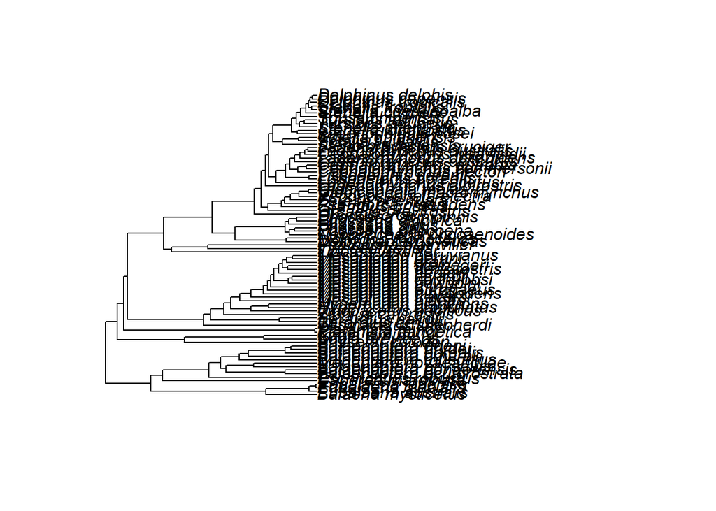

```r
library(ape)
whaleTree<-read.tree("cetacea.phy")
plot(whaleTree)
```

```r
newWhale<-drop.tip(whaleTree, "Balaena_mysticetus")
write.tree(newWhale, file="prunedWhales.phy")
```